# Effects of Credit Scores and Income on Loan Payments

## by Gloria V

## Investigation Overview

I wanted to see how correlated were the Credit Scores and Prosper Ratings with the actual maintenance of the Loan. In other words, how accurate the Ratings have been in the prediction of the loan health.

## Dataset Overview

The dataset has 113,937 loans with 81 features. A good amount of the attributes are numeric as it would be expected for a financial dataset. There are also boolean attributes as well as some defined as objects.

## Distribution of Loans by Status

In the graphic below we can see the distribution of the Status of Loans. How would you feel is either investor or potential borrower? I kind of not feel reassured with the amount of loans Charged off, Defaulted and Past Due.

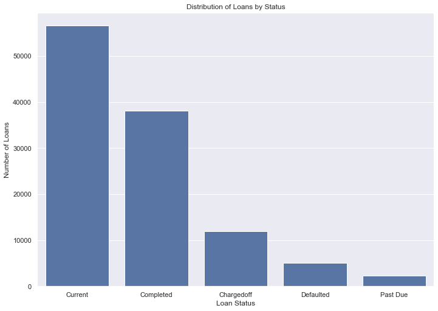

```python
# build graph
base_color = sb.color_palette()[0]
sb.countplot(data = df, x = 'LoanStatusSummary', color = base_color, order = type_order);
plt.title('Distribution of Loans by Status')
plt.xlabel('Loan Status')
plt.ylabel('Number of Loans');
```

### Loan Status vs. Stated Monthly Income

Based on the plot shown below, I can see that they are kind of homogeneous between each other.

There is no outstanding difference between the status a loan is maintained and the reported monthly income.

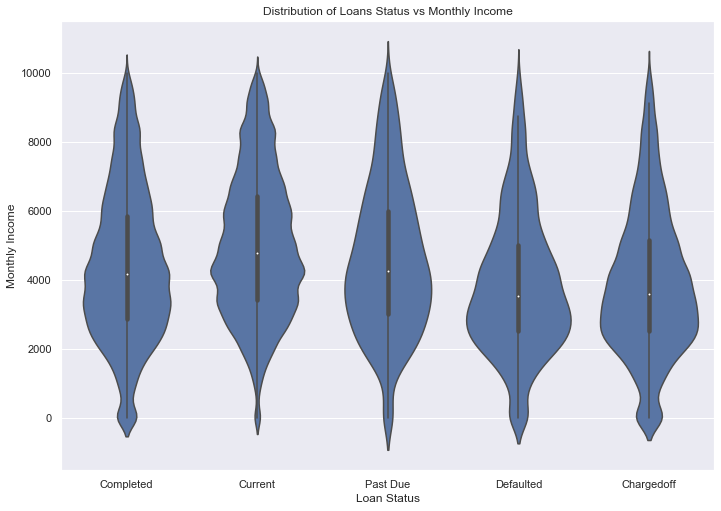

```python
base_color = sb.color_palette()[0]
sb.violinplot(data = df[df['StatedMonthlyIncome'] < 10000],
                    x = 'LoanStatusSummary', y = 'StatedMonthlyIncome', color = base_color)
plt.title('Distribution of Loans Status vs Monthly Income')
plt.ylabel('Monthly Income')
plt.xlabel('Loan Status');
```

### Loan Status vs. Credit Score

In this graph we can see that for all Loan Status except Current, the Credit Score Below Average is more prevalent. That ratio is more prevalent on the Charged Off and Defaulted Loans.

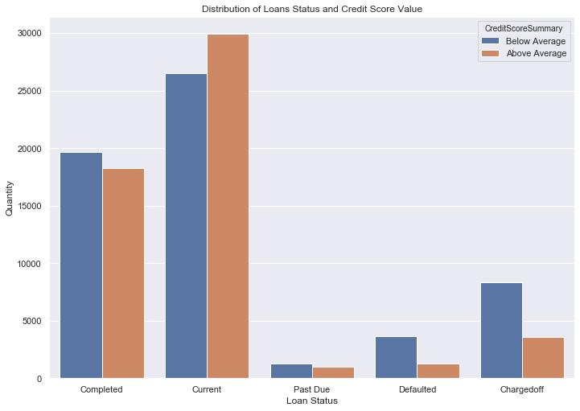

```python
sb.countplot(data = df, x = 'LoanStatusSummary', hue = 'CreditScoreSummary')
plt.title('Distribution of Loans Status and Credit Score Value')
plt.ylabel('Quantity')
plt.xlabel('Loan Status');
```